# Class

```python
%matplotlib inline
```

```python
import os
os.environ["KMP_DUPLICATE_LIB_OK"]  =  "TRUE"
import scipy.io as scio
from PIL import Image
from sklearn import svm
from sklearn import preprocessing
import sklearn
import torch.nn.functional as F
import cvxpy as cp
import cv2 as cv
import numpy as np
import tifffile as tiff
import pandas as pd
from skimage import color, io
import matplotlib.pyplot as plt
import torch
from torch import nn
import imgviz
import pickle
from joblib import dump, load
```

## 高光谱图像分类

### 图像分类

在高光谱图像处理的众多研究方向中，图像分类无疑是竞争最激烈的。 在传统的光学图像中，分类和分割有较大的区别

[figure not shown]

图像分类是将一张图像分为某一类，这种任务一张图片只包含一种事务。

### 实例分割

图像分割又叫做实例分割，它和图像分类最大的区别的是：图像分割数据集中每一张图片都包含1种或者一种以上的物体，图像分割就是将不同的物体在图片中区分出来。

[figure not shown]

但是在高光谱图像中，由于混合像元的存在以及高光谱图像本身就有的物质识别能力，高光谱图像的分类和分割界限不想光学图像那么明确。

```python
def get_dataset():

    img = scio.loadmat("./Data/Indian_pines_corrected.mat")["indian_pines_corrected"]
    gt = scio.loadmat("./Data/Indian_pines_gt.mat")["indian_pines_gt"]
    rgb_bands = (43, 21, 11)  # AVIRIS sensor
    label_values = ["Undefined", "Alfalfa", "Corn-notill", "Corn-mintill",
                        "Corn", "Grass-pasture", "Grass-trees",
                        "Grass-pasture-mowed", "Hay-windrowed", "Oats",
                        "Soybean-notill", "Soybean-mintill", "Soybean-clean",
                        "Wheat", "Woods", "Buildings-Grass-Trees-Drives",
                        "Stone-Steel-Towers"]
    ignored_labels = [0]
    img = np.asarray(img, dtype='float32')
    data = img.reshape(np.prod(img.shape[:2]), np.prod(img.shape[2:]))
    data  = preprocessing.minmax_scale(data)
    img = data.reshape(img.shape)

    return img, gt, label_values, ignored_labels, rgb_bands
```

```python
def build_dataset(mat, gt, ignored_labels=None):

    samples = []
    labels = []
    # Check that image and ground truth have the same 2D dimensions
    assert mat.shape[:2] == gt.shape[:2]

    for label in np.unique(gt):
        if label in ignored_labels:
            continue
        else:
            indices = np.nonzero(gt == label)
            samples += list(mat[indices])
            labels += len(indices[0]) * [label]
    return np.asarray(samples), np.asarray(labels)
```

```python
def sample_gt(gt, train_size, mode='random'):
    """Extract a fixed percentage of samples from an array of labels.

    Args:
        gt: a 2D array of int labels
        percentage: [0, 1] float
    Returns:
        train_gt, test_gt: 2D arrays of int labels

    """
    indices = np.nonzero(gt)
    X = list(zip(*indices)) # x,y features
    y = gt[indices].ravel() # classes
    train_gt = np.zeros_like(gt)
    test_gt = np.zeros_like(gt)
    if train_size > 1:
       train_size = int(train_size)

    if mode == 'random':
       train_indices, test_indices = sklearn.model_selection.train_test_split(X, train_size=train_size, stratify=y)
       train_indices = [list(t) for t in zip(*train_indices)]
       test_indices = [list(t) for t in zip(*test_indices)]
       train_gt[tuple(train_indices)] = gt[tuple(train_indices)]
       test_gt[tuple(test_indices)] = gt[tuple(test_indices)]
    elif mode == 'fixed':
       print("Sampling {} with train size = {}".format(mode, train_size))
       train_indices, test_indices = [], []
       for c in np.unique(gt):
           if c == 0:
              continue
           indices = np.nonzero(gt == c)
           X = list(zip(*indices)) # x,y features

           train, test = sklearn.model_selection.train_test_split(X, train_size=train_size)
           train_indices += train
           test_indices += test
       train_indices = [list(t) for t in zip(*train_indices)]
       test_indices = [list(t) for t in zip(*test_indices)]
       train_gt[train_indices] = gt[train_indices]
       test_gt[test_indices] = gt[test_indices]

    elif mode == 'disjoint':
        train_gt = np.copy(gt)
        test_gt = np.copy(gt)
        for c in np.unique(gt):
            mask = gt == c
            for x in range(gt.shape[0]):
                first_half_count = np.count_nonzero(mask[:x, :])
                second_half_count = np.count_nonzero(mask[x:, :])
                try:
                    ratio = first_half_count / second_half_count
                    if ratio > 0.9 * train_size and ratio < 1.1 * train_size:
                        break
                except ZeroDivisionError:
                    continue
            mask[:x, :] = 0
            train_gt[mask] = 0

        test_gt[train_gt > 0] = 0
    else:
        raise ValueError("{} sampling is not implemented yet.".format(mode))
    return train_gt, test_gt
```

```python
img, gt, label_values, ignored_labels, rgb_bands = get_dataset()
N_class = len(label_values)
N_bands = img.shape[-1]
```

```python
train_gt, test_gt = sample_gt(gt, 0.99)
X_train, y_train = build_dataset(img, train_gt,
                                         ignored_labels=ignored_labels)
```

```python
# clf = sklearn.svm.SVC(gamma=1, class_weight='balanced')
# clf.fit(X_train, y_train)
# dump(clf, './clf.joblib')
clf = load('./clf.joblib')
prediction = clf.predict(img.reshape(-1, N_bands,))
prediction = prediction.reshape(img.shape[:2])
```

```python
mask = np.zeros(gt.shape, dtype='bool')
for l in ignored_labels:
        mask[gt == l] = True
prediction[mask] = 0
```

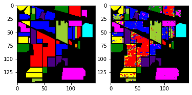

```python
rgb_image = color.label2rgb(prediction)

# io.imshow(rgb_image)
# io.show()
rgb_image_GT = color.label2rgb(gt)

# io.imshow(rgb_image_GT)
# io.show()
plt.subplot(1,2,1)
plt.imshow(rgb_image_GT)

plt.subplot(1,2,2)
plt.imshow(rgb_image)
```

## 高光谱图像解混

高光谱图像解混可以看做是一种无监督的的图像分类，通过高光谱图像解混算法可以得到图像对应的端元矩阵与丰度矩阵。其中丰度矩阵可以看做是每个像素中包含不同端元的比例，将含量最多的那一个端元当做该像素所属的类别就可以得到分类结果。

[figure not shown]

```
residual norm 2.4494897875222357
```

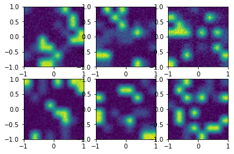

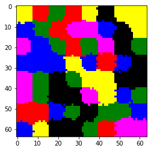

```python
class UNMF_Net(nn.Module):
    def __init__(self, layerNum, M, A):
        super(UNMF_Net, self).__init__()
        R = np.size(M, 1)
        eig, _ = np.linalg.eig(M.T @ M)
        eig += 0.1
        L = 1 / np.max(eig)
        theta = np.ones((1, R)) * 0.01 * L
        # Endmember
        eig, _ = np.linalg.eig(A @ A.T)
        eig += 0.1
        L2 = np.max(eig)
        L2 = 1 / L2

        self.p = nn.ParameterList()
        self.L = nn.ParameterList()
        self.theta = nn.ParameterList()
        self.L2 = nn.ParameterList()
        self.W_a = nn.ParameterList()
        self.layerNum = layerNum
        temp = self.calW(M)
        for k in range(self.layerNum):
            self.L.append(nn.Parameter(torch.FloatTensor([L])))
            self.L2.append(nn.Parameter(torch.FloatTensor([L2])))
            self.theta.append(nn.Parameter(torch.FloatTensor(theta)))
            self.p.append(nn.Parameter(torch.FloatTensor([0.5])))
            self.W_a.append(nn.Parameter(torch.FloatTensor(temp)))
        self.layerNum = layerNum
    def forward(self, X, _M, _A):
        self.W_m = torch.FloatTensor(_A)
        M = list()
        M.append(torch.FloatTensor(_M))
        A = list()
        A.append(torch.FloatTensor(_A.T))
        for k in range(self.layerNum):
            theta = self.theta[k].repeat(A[-1].size(1), 1).T
            T = M[-1].mm(A[-1]) - X
            _A = A[-1] - self.L[k]*self.W_a[k].T.mm(T)
            _A = self.sum2one(F.relu(self.self_active(_A, self.p[k], theta)))
            A.append(_A)
            T = M[-1].mm(A[-1]) - X
            _M = M[-1] - T.mm(self.L2[k] * self.W_m)
            _M = F.relu(_M)
            M.append(_M)
        return M, A

    def self_active(self, x, p, lam):
        tau=pow(2*(1-p)*lam,1/(2-p))+p*lam*pow(2*lam*(1-p), (p-1)/(2-p))
        v = x
        ind = (x-tau) > 0
        ind2=(x-tau)<=0
        v[ind]=x[ind].sign() * (x[ind].abs() - p * lam[ind] * pow(x[ind].abs(), p - 1))
        v[ind2]=0
        v[v>1]=1
        return v
    def calW(self,D):
        (m,n)=D.shape
        W = cp.Variable(shape=(m, n))
        obj = cp.Minimize(cp.norm(W.T @ D, 'fro'))
        # Create two constraints.
        constraint = [cp.diag(W.T @ D) == 1]
        prob = cp.Problem(obj, constraint)
        result = prob.solve(solver=cp.SCS, max_iters=1000)
        print('residual norm {}'.format(prob.value))
        # print(W.value)
        return W.value
    def sum2one(self, Z):
        temp = Z.sum(0)
        temp = temp.repeat(Z.size(0), 1) + 0.0001
        return Z / temp
A0 = np.random.randn(224, 6)
S0 = np.random.randn(6, 4096)
model = UNMF_Net(9, A0, S0)
checkpoint = torch.load("./net_params_1123500.pkl")
dataFile = ".//Data//syntheticDataNewSNR20dB20170601.mat"
data = scio.loadmat(dataFile)
X = data['x_n']
A = data['A']
s = data['s']
X = torch.tensor(X, dtype = torch.float32)
# A = torch.tensor(A)
s = torch.tensor(s, dtype = torch.float32)
model.load_state_dict(checkpoint)
model.eval()
# O1, O2 = checkpoint(X, A, s)
End, Abd = model(X, A, s)

A1 = Abd[9].T
A1 = torch.reshape(A1, [64, 64, -1]).detach().numpy()
for i in range(6):
    plt.subplot(2,3,i+1)
    plt.imshow(A1[:,:,i], extent=[-1, 1, -1, 1])

plt.show()
Class = np.argmax(A1, axis=2)
image_class = color.label2rgb(Class)
plt.imshow(image_class)
plt.show()
```

## 高光谱图像变化检测

高光谱图像的变化检测是检测同一区域不同时间的两张图片中发生变化的区域。 变化检测又分为多变化检测和简单的变化检测。其中多变化检测要求在找出图片中发生变化的区域的同时要能判断出到底发生了哪一种变化，它实际上可以抽象为一种多分类问题。

[figure not shown]

变化检测中的另一种形式是单变化检测，只需要检测出变化的区域即可，不需要确定变化的具体类型。

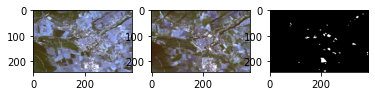

```python
img1=cv.imread("./Data/img1.png")
img2=cv.imread("./Data/img2.png")
cm=cv.imread("./Data/cm.png")

plt.subplot(1,3,1)
plt.imshow(img1)

plt.subplot(1,3,2)
plt.imshow(img2)

plt.subplot(1,3,3)
plt.imshow(cm)
```

这类问题可以抽象为一个简单的二分类问题，但是发生变化的区域相比于没有变化的区域往往是非常少的，因此这类问题中要着重考虑不平衡样本所带来的问题。

[figure not shown]

```python
class OSCD(nn.Module):
    def __init__(self):
        super (OSCD, self).__init__()
        self.encoder1 = nn.Sequential(
            nn.Linear(13, 8, bias=True),
            nn.ReLU(),
             nn.Linear(8, 4, bias=True),
            nn.ReLU(),
        )
        self.decoder1 = nn.Sequential(
            nn.Linear(4, 8, bias=True),
            nn.ReLU(),
            nn.Linear(8, 13, bias=True),
            nn.ReLU(),
        )
        self.encoder2 = nn.Sequential(
            nn.Linear(13, 8, bias=True),
            nn.ReLU(),
             nn.Linear(8, 4, bias=True),
            nn.ReLU(),
        )
        self.decoder2 = nn.Sequential(
            nn.Linear(4, 8, bias=True),
            nn.ReLU(),
            nn.Linear(8, 13, bias=True),
            nn.ReLU(),
        )
        self.out = nn.Sequential(
            nn.Linear(13, 4),
            nn.ReLU(),
            nn.Linear(4, 2),
            nn.Sigmoid(),
        )

    def forward(self, input1, input2):
        hide1 = self.encoder1(input1)
        feature1 = self.decoder1(hide1)

        diff1 = feature1 - input2

        hide2 = self.encoder2(input2)
        feature2 = self.decoder2(hide2)

        diff2 = feature2 - input1

        diff = torch.minimum(diff1, diff2)
        out = self.out(diff)
        return out
```

```python
# model = OSCD()
# device = torch.device("cuda" if torch.cuda.is_available() else "cpu")
# model = model.to(device)
# checkpoint = torch.load(".//CD2.pt", map_location=device)
# model.load_state_dict(checkpoint)
# model.eval()
OSCD = sklearn.svm.SVC(gamma=0.8)
```

```python
input1 = scio.loadmat("./Data/norcia.mat")['img1']
input2 = scio.loadmat("./Data/norcia.mat")['img2']
img1 = input1
img2 = input2
img1 = input1[41:241,185:385,:]
img2 = input2[41:241,185:385,:]
in1 = input1.reshape(-1, 13)
in2 = input2.reshape(-1, 13)
img1 = img1.reshape(-1,13)
img2 = img2.reshape(-1,13)
# max_img1 = np.max(input1)
# input1 = input1.astype(np.float32)/max_img1

# max_img2 = np.max(input2)
# input2 = input2.astype(np.float32)/max_img2

label = tiff.imread("./Data/norcia-cm.tif")
label = label[41:241,185:385]
label = label - 1
label = label.reshape(-1)
        # label = label.astype(np.float32)

# img1 = torch.reshape(torch.tensor(input1),(-1, 13))
# img2 = torch.reshape(torch.tensor(input2),(-1, 13))
# target = torch.reshape(torch.tensor(label),(-1,))
```

```python
# OSCD.fit(img1 - img2, label)
# dump(OSCD, './OSCD.joblib')
OSCD = load('./OSCD.joblib')
```

```python
map = OSCD.predict(in1 - in2)
```

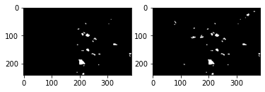

```python
map = map.reshape(241, 385,1)
# map = model(img1.to(device), img2.to(device))
# map = torch.argmax(map,dim = 1)
# map = torch.reshape(map,(241, 385)).cpu().numpy()
map1 = np.concatenate((map, map, map), axis=2)
plt.subplot(1,2,1)
plt.imshow(map1*255)
plt.subplot(1,2,2)
plt.imshow(cm)
```

```python
GT = tiff.imread("./Data/norcia-cm.tif")
GT = GT - 1
out = map.reshape(241, 385)-GT
acc = 1-((np.count_nonzero(out))/(map.shape[0]*map.shape[1]))
print("变化检测的准确率是",acc)
```

```
变化检测的准确率是 0.9969607156329148
```

```python
fake = np.zeros_like(GT)
out1 = fake - GT
f_acc = 1-((np.count_nonzero(out1))/(map.shape[0]*map.shape[1]))
print("变化检测的准确率是",f_acc)
```

```
变化检测的准确率是 0.9867758797219378
```